# Water Quality Analytics

```python
import pandas as pd

import os, types
import pandas as pd
from botocore.client import Config
import ibm_boto3

def __iter__(self): return 0

# @hidden_cell
# The following code accesses a file in your IBM Cloud Object Storage. It includes your credentials.
# You might want to remove those credentials before you share the notebook.
cos_client = ibm_boto3.client(service_name='s3',
    ibm_api_key_id='GFURuYfs9uLRAie_Ty6_N0ixUJhw6svgVbRA7VtpsppH',
    ibm_auth_endpoint="https://iam.cloud.ibm.com/oidc/token",
    config=Config(signature_version='oauth'),
    endpoint_url='https://s3.private.eu-de.cloud-object-storage.appdomain.cloud')

bucket = 'waterquality-donotdelete-pr-h0r0jxyglqzd3n'
object_key = 'Water Quality Testing (1).csv'

body = cos_client.get_object(Bucket=bucket,Key=object_key)['Body']
# add missing __iter__ method, so pandas accepts body as file-like object
if not hasattr(body, "__iter__"): body.__iter__ = types.MethodType( __iter__, body )

df= pd.read_csv(body)
df
```

|  | Sample ID | Temperature (°C) | Turbidity (NTU) | Dissolved Oxygen (mg/L) | Conductivity (µS/cm) | ph | Hardness | Solids | Chloramines | Sulfate | Conductivity | Organic_carbon | Trihalomethanes | Turbidity | Potability |
| --- | --- | --- | --- | --- | --- | --- | --- | --- | --- | --- | --- | --- | --- | --- | --- |
| 0 | 1.0 | 23.1 | 4.5 | 7.8 | 342.0 | NaN | 204.890456 | 20791.31898 | 7.300212 | 368.516441 | 564.308654 | 10.379783 | 86.990970 | 2.963135 | 0 |
| 1 | 2.0 | 22.3 | 5.1 | 6.2 | 335.0 | 3.716080 | 129.422921 | 18630.05786 | 6.635246 | NaN | 592.885359 | 15.180013 | 56.329076 | 4.500656 | 0 |
| 2 | 3.0 | 21.5 | 3.9 | 8.3 | 356.0 | 8.099124 | 224.236259 | 19909.54173 | 9.275884 | NaN | 418.606213 | 16.868637 | 66.420093 | 3.055934 | 0 |
| 3 | 4.0 | 22.9 | 3.2 | 9.5 | 327.0 | 8.316766 | 214.373394 | 22018.41744 | 8.059332 | 356.886136 | 363.266516 | 18.436525 | 100.341674 | 4.628771 | 0 |
| 4 | 5.0 | 20.7 | 3.8 | 8.1 | 352.0 | 9.092223 | 181.101509 | 17978.98634 | 6.546600 | 310.135738 | 398.410813 | 11.558279 | 31.997993 | 4.075075 | 0 |
| ... | ... | ... | ... | ... | ... | ... | ... | ... | ... | ... | ... | ... | ... | ... | ... |
| 3271 | NaN | NaN | NaN | NaN | NaN | 4.668102 | 193.681736 | 47580.99160 | 7.166639 | 359.948574 | 526.424171 | 13.894419 | 66.687695 | 4.435821 | 1 |
| 3272 | NaN | NaN | NaN | NaN | NaN | 7.808856 | 193.553212 | 17329.80216 | 8.061362 | NaN | 392.449580 | 19.903225 | NaN | 2.798243 | 1 |
| 3273 | NaN | NaN | NaN | NaN | NaN | 9.419510 | 175.762646 | 33155.57822 | 7.350233 | NaN | 432.044783 | 11.039070 | 69.845400 | 3.298875 | 1 |
| 3274 | NaN | NaN | NaN | NaN | NaN | 5.126763 | 230.603758 | 11983.86938 | 6.303357 | NaN | 402.883113 | 11.168946 | 77.488213 | 4.708658 | 1 |
| 3275 | NaN | NaN | NaN | NaN | NaN | 7.874671 | 195.102299 | 17404.17706 | 7.509306 | NaN | 327.459761 | 16.140368 | 78.698446 | 2.309149 | 1 |

3276 rows × 15 columns

## We can come to a conclusion the full CSVfile

```python
print(df.shape)
```

```
(3276, 15)
```

## We can come to a conclusion that in csv file how many rowsand columns are their in CSVfile

```python
print(df.columns)
```

```
Index(['Sample ID', 'Temperature (°C)', 'Turbidity (NTU)',
       'Dissolved Oxygen (mg/L)', 'Conductivity (µS/cm)', 'ph', 'Hardness',
       'Solids', 'Chloramines', 'Sulfate', 'Conductivity', 'Organic_carbon',
       'Trihalomethanes', 'Turbidity', 'Potability'],
      dtype='object')
```

## We can come to a conclusion that in CSV File that how many column are there

```python
print(df.dtypes)
```

```
Sample ID                  float64
Temperature (°C)           float64
Turbidity (NTU)            float64
Dissolved Oxygen (mg/L)    float64
Conductivity (µS/cm)       float64
ph                         float64
Hardness                   float64
Solids                     float64
Chloramines                float64
Sulfate                    float64
Conductivity               float64
Organic_carbon             float64
Trihalomethanes            float64
Turbidity                  float64
Potability                   int64
dtype: object
```

## We can come to a conclusion that in CSV File that what type of datatype in this file

```python
df.info()
```

```
<class 'pandas.core.frame.DataFrame'>
RangeIndex: 3276 entries, 0 to 3275
Data columns (total 15 columns):
 #   Column                   Non-Null Count  Dtype
---  ------                   --------------  -----
 0   Sample ID                500 non-null    float64
 1   Temperature (°C)         500 non-null    float64
 2   Turbidity (NTU)          500 non-null    float64
 3   Dissolved Oxygen (mg/L)  500 non-null    float64
 4   Conductivity (µS/cm)     500 non-null    float64
 5   ph                       2785 non-null   float64
 6   Hardness                 3276 non-null   float64
 7   Solids                   3276 non-null   float64
 8   Chloramines              3276 non-null   float64
 9   Sulfate                  2495 non-null   float64
 10  Conductivity             3276 non-null   float64
 11  Organic_carbon           3276 non-null   float64
 12  Trihalomethanes          3114 non-null   float64
 13  Turbidity                3276 non-null   float64
 14  Potability               3276 non-null   int64
dtypes: float64(14), int64(1)
memory usage: 384.0 KB
```

## We can come to a conclusion that in CSV File that it give full information about the file like storage,datatypes etc.

```python
print(df.head(n=10))
```

```
   Sample ID  Temperature (°C)  Turbidity (NTU)  Dissolved Oxygen (mg/L)  \
0        1.0              23.1              4.5                      7.8
1        2.0              22.3              5.1                      6.2
2        3.0              21.5              3.9                      8.3
3        4.0              22.9              3.2                      9.5
4        5.0              20.7              3.8                      8.1
5        6.0              23.6              4.6                      7.2
6        7.0              21.2              4.2                      8.8
7        8.0              22.1              3.7                      6.9
8        9.0              20.4              4.1                      8.4
9       10.0              22.7              4.8                      7.5

   Conductivity (µS/cm)         ph    Hardness       Solids  Chloramines  \
0                 342.0        NaN  204.890456  20791.31898     7.300212
1                 335.0   3.716080  129.422921  18630.05786     6.635246
```

[output cut: 32 more lines]

## We can come to a conclusion that from first it take 10 data from CSV File

```python
print(df.tail(n=10))
```

```
      Sample ID  Temperature (°C)  Turbidity (NTU)  Dissolved Oxygen (mg/L)  \
3266        NaN               NaN              NaN                      NaN
3267        NaN               NaN              NaN                      NaN
3268        NaN               NaN              NaN                      NaN
3269        NaN               NaN              NaN                      NaN
3270        NaN               NaN              NaN                      NaN
3271        NaN               NaN              NaN                      NaN
3272        NaN               NaN              NaN                      NaN
3273        NaN               NaN              NaN                      NaN
3274        NaN               NaN              NaN                      NaN
3275        NaN               NaN              NaN                      NaN

      Conductivity (µS/cm)         ph    Hardness       Solids  Chloramines  \
3266                   NaN   8.372910  169.087052  14622.74549     7.547984
3267                   NaN   8.989900  215.047358  15921.41202     6.297312
```

[output cut: 32 more lines]

## We can come to a conclusion that from last it take 10 data from CSV File

## We can come to a conclusion boolean same-sized object indicating if the values are NA. NA values, such as None or numpy.NaN, gets mapped to True values. Everything else gets mapped to False values.

```python
water_backup = df.copy()
```

```python
missing_water_data = water_backup[water_backup.isnull().any(axis=1)]
missing_water_data
```

|  | Sample ID | Temperature (°C) | Turbidity (NTU) | Dissolved Oxygen (mg/L) | Conductivity (µS/cm) | ph | Hardness | Solids | Chloramines | Sulfate | Conductivity | Organic_carbon | Trihalomethanes | Turbidity | Potability |
| --- | --- | --- | --- | --- | --- | --- | --- | --- | --- | --- | --- | --- | --- | --- | --- |
| 0 | 1.0 | 23.1 | 4.5 | 7.8 | 342.0 | NaN | 204.890456 | 20791.31898 | 7.300212 | 368.516441 | 564.308654 | 10.379783 | 86.990970 | 2.963135 | 0 |
| 1 | 2.0 | 22.3 | 5.1 | 6.2 | 335.0 | 3.716080 | 129.422921 | 18630.05786 | 6.635246 | NaN | 592.885359 | 15.180013 | 56.329076 | 4.500656 | 0 |
| 2 | 3.0 | 21.5 | 3.9 | 8.3 | 356.0 | 8.099124 | 224.236259 | 19909.54173 | 9.275884 | NaN | 418.606213 | 16.868637 | 66.420093 | 3.055934 | 0 |
| 8 | 9.0 | 20.4 | 4.1 | 8.4 | 360.0 | NaN | 118.988579 | 14285.58385 | 7.804174 | 268.646941 | 389.375566 | 12.706049 | 53.928846 | 3.595017 | 0 |
| 11 | 12.0 | 21.6 | 3.6 | 7.1 | 328.0 | 7.974522 | 218.693300 | 18767.65668 | 8.110385 | NaN | 364.098230 | 14.525746 | 76.485911 | 4.011718 | 0 |
| ... | ... | ... | ... | ... | ... | ... | ... | ... | ... | ... | ... | ... | ... | ... | ... |
| 3271 | NaN | NaN | NaN | NaN | NaN | 4.668102 | 193.681736 | 47580.99160 | 7.166639 | 359.948574 | 526.424171 | 13.894419 | 66.687695 | 4.435821 | 1 |
| 3272 | NaN | NaN | NaN | NaN | NaN | 7.808856 | 193.553212 | 17329.80216 | 8.061362 | NaN | 392.449580 | 19.903225 | NaN | 2.798243 | 1 |
| 3273 | NaN | NaN | NaN | NaN | NaN | 9.419510 | 175.762646 | 33155.57822 | 7.350233 | NaN | 432.044783 | 11.039070 | 69.845400 | 3.298875 | 1 |
| 3274 | NaN | NaN | NaN | NaN | NaN | 5.126763 | 230.603758 | 11983.86938 | 6.303357 | NaN | 402.883113 | 11.168946 | 77.488213 | 4.708658 | 1 |
| 3275 | NaN | NaN | NaN | NaN | NaN | 7.874671 | 195.102299 | 17404.17706 | 7.509306 | NaN | 327.459761 | 16.140368 | 78.698446 | 2.309149 | 1 |

2958 rows × 15 columns

```python
water_backup.describe()
```

|  | Sample ID | Temperature (°C) | Turbidity (NTU) | Dissolved Oxygen (mg/L) | Conductivity (µS/cm) | ph | Hardness | Solids | Chloramines | Sulfate | Conductivity | Organic_carbon | Trihalomethanes | Turbidity | Potability |
| --- | --- | --- | --- | --- | --- | --- | --- | --- | --- | --- | --- | --- | --- | --- | --- |
| count | 500.000000 | 500.000000 | 500.000000 | 500.000000 | 500.000000 | 2785.000000 | 3276.000000 | 3276.000000 | 3276.000000 | 2495.000000 | 3276.000000 | 3276.000000 | 3114.000000 | 3276.000000 | 3276.000000 |
| mean | 250.500000 | 22.054400 | 4.169400 | 8.382200 | 344.362000 | 7.080795 | 196.369496 | 22014.092526 | 7.122277 | 333.775777 | 426.205111 | 14.284970 | 66.396293 | 3.966786 | 0.390110 |
| std | 144.481833 | 0.903123 | 0.397492 | 0.822396 | 13.038672 | 1.594320 | 32.879761 | 8768.570828 | 1.583085 | 41.416840 | 80.824064 | 3.308162 | 16.175008 | 0.780382 | 0.487849 |
| min | 1.000000 | 20.300000 | 3.100000 | 6.000000 | 316.000000 | 0.000000 | 47.432000 | 320.942611 | 0.352000 | 129.000000 | 181.483754 | 2.200000 | 0.738000 | 1.450000 | 0.000000 |
| 25% | 125.750000 | 21.200000 | 3.800000 | 7.800000 | 333.000000 | 6.093092 | 176.850538 | 15666.690300 | 6.127421 | 307.699498 | 365.734414 | 12.065801 | 55.844536 | 3.439711 | 0.000000 |
| 50% | 250.500000 | 22.200000 | 4.200000 | 8.400000 | 344.000000 | 7.036752 | 196.967627 | 20927.833605 | 7.130299 | 333.073546 | 421.884968 | 14.218338 | 66.622485 | 3.955028 | 0.000000 |
| 75% | 375.250000 | 22.900000 | 4.500000 | 9.100000 | 355.000000 | 8.062066 | 216.667456 | 27332.762125 | 8.114887 | 359.950170 | 481.792305 | 16.557652 | 77.337473 | 4.500320 | 1.000000 |
| max | 500.000000 | 23.600000 | 5.100000 | 9.900000 | 370.000000 | 14.000000 | 323.124000 | 61227.196010 | 13.127000 | 481.030642 | 753.342620 | 28.300000 | 124.000000 | 6.739000 | 1.000000 |

## We can come to a conclusion that describe of water backup in csv file

```python
water_backup['Temperature (°C)'].mean()
```

```
22.054399999999998
```

## We can come to a conclusion that describe water's temperature mean by mean value

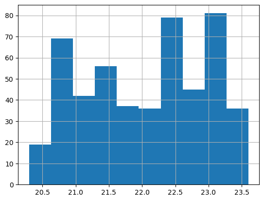

```python
df['Temperature (°C)'].hist()
```

```python
df['Potability'].value_counts()
```

```
Potability
0    1998
1    1278
Name: count, dtype: int64
```

```python
pd.crosstab(index=water_backup['Potability'],columns='Count',dropna=True)
```

| col_0 Potability | Count |
| --- | --- |
| 0 | 1998 |
| 1 | 1278 |

```python
import numpy as np
import matplotlib.pyplot as plt
```

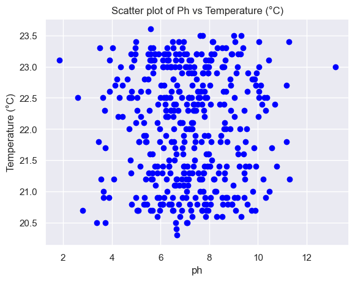

```python
plt.scatter(water_backup['ph'],water_backup['Temperature (°C)'], c='blue')
plt.title('Scatter plot of Ph vs Temperature (°C)')
plt.xlabel('ph')
plt.ylabel('Temperature (°C)')
```

## We can come to a conclusion that in scatter plot we are giving ph vs temperature of water

```python
import seaborn as sns
```

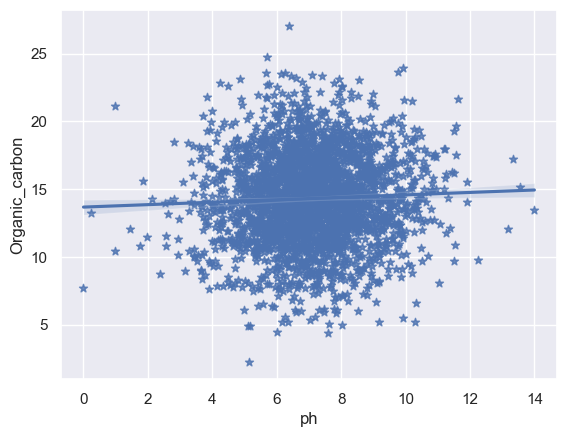

```python
sns.set(style="darkgrid")
sns.regplot(x=water_backup['ph'],y=water_backup['Organic_carbon'],fit_reg=True, marker="*")
```

## We can come to a conclusion that by seaborn scatterplot we are giving ph vs age of organic carbon between 6to 8 ph value is 14 organic _carbon

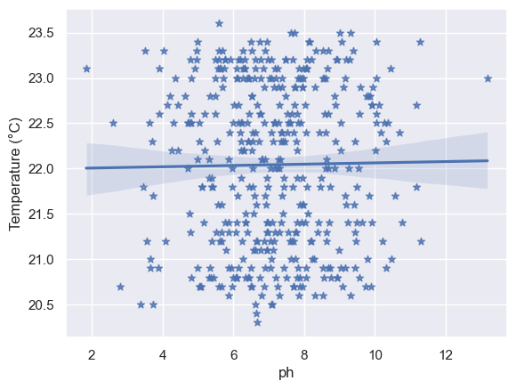

```python
sns.set(style="darkgrid")
sns.regplot(x=water_backup['ph'],y=water_backup['Temperature (°C)'],fit_reg=True, marker="*")
```

## We can come to a conclusion that by seaborn scatterplot we are giving ph vs temperature in water . Drinking water has a pH range of 6.5 to 8.5 between 50 and 72 degrees Fahrenheit (10-22 degrees Celsius)

```python
df.corr()
```

|  | Sample ID | Temperature (°C) | Turbidity (NTU) | Dissolved Oxygen (mg/L) | Conductivity (µS/cm) | ph | Hardness | Solids | Chloramines | Sulfate | Conductivity | Organic_carbon | Trihalomethanes | Turbidity | Potability |
| --- | --- | --- | --- | --- | --- | --- | --- | --- | --- | --- | --- | --- | --- | --- | --- |
| Sample ID | 1.000000 | -0.059358 | 0.118832 | 0.180574 | 0.184919 | -0.030086 | 0.002391 | -0.029053 | 0.017114 | -0.016579 | 0.035415 | 0.008943 | -0.035268 | 0.013393 | 0.380217 |
| Temperature (°C) | -0.059358 | 1.000000 | -0.232663 | 0.246976 | 0.317573 | 0.013581 | -0.043321 | -0.048724 | 0.018581 | -0.107971 | 0.047270 | 0.031731 | 0.080051 | 0.050883 | -0.047065 |
| Turbidity (NTU) | 0.118832 | -0.232663 | 1.000000 | -0.275270 | -0.087372 | 0.032060 | -0.018651 | 0.050171 | 0.002563 | 0.054904 | -0.035939 | -0.083066 | -0.090868 | 0.001274 | 0.075537 |
| Dissolved Oxygen (mg/L) | 0.180574 | 0.246976 | -0.275270 | 1.000000 | 0.760700 | -0.008575 | 0.009709 | -0.018446 | -0.023963 | 0.003453 | 0.003349 | 0.065872 | 0.099565 | -0.047865 | 0.089489 |
| Conductivity (µS/cm) | 0.184919 | 0.317573 | -0.087372 | 0.760700 | 1.000000 | -0.007207 | -0.029428 | -0.002321 | 0.036903 | 0.014860 | 0.032279 | 0.068139 | 0.084895 | -0.029669 | 0.096469 |
| ph | -0.030086 | 0.013581 | 0.032060 | -0.008575 | -0.007207 | 1.000000 | 0.082096 | -0.089288 | -0.034350 | 0.018203 | 0.018614 | 0.043503 | 0.003354 | -0.039057 | -0.003556 |
| Hardness | 0.002391 | -0.043321 | -0.018651 | 0.009709 | -0.029428 | 0.082096 | 1.000000 | -0.046899 | -0.030054 | -0.106923 | -0.023915 | 0.003610 | -0.013013 | -0.014449 | -0.013837 |
| Solids | -0.029053 | -0.048724 | 0.050171 | -0.018446 | -0.002321 | -0.089288 | -0.046899 | 1.000000 | -0.070148 | -0.171804 | 0.013831 | 0.010242 | -0.009143 | 0.019546 | 0.033743 |
| Chloramines | 0.017114 | 0.018581 | 0.002563 | -0.023963 | 0.036903 | -0.034350 | -0.030054 | -0.070148 | 1.000000 | 0.027244 | -0.020486 | -0.012653 | 0.017084 | 0.002363 | 0.023779 |
| Sulfate | -0.016579 | -0.107971 | 0.054904 | 0.003453 | 0.014860 | 0.018203 | -0.106923 | -0.171804 | 0.027244 | 1.000000 | -0.016121 | 0.030831 | -0.030274 | -0.011187 | -0.023577 |
| Conductivity | 0.035415 | 0.047270 | -0.035939 | 0.003349 | 0.032279 | 0.018614 | -0.023915 | 0.013831 | -0.020486 | -0.016121 | 1.000000 | 0.020966 | 0.001285 | 0.005798 | -0.008128 |
| Organic_carbon | 0.008943 | 0.031731 | -0.083066 | 0.065872 | 0.068139 | 0.043503 | 0.003610 | 0.010242 | -0.012653 | 0.030831 | 0.020966 | 1.000000 | -0.013274 | -0.027308 | -0.030001 |
| Trihalomethanes | -0.035268 | 0.080051 | -0.090868 | 0.099565 | 0.084895 | 0.003354 | -0.013013 | -0.009143 | 0.017084 | -0.030274 | 0.001285 | -0.013274 | 1.000000 | -0.022145 | 0.007130 |
| Turbidity | 0.013393 | 0.050883 | 0.001274 | -0.047865 | -0.029669 | -0.039057 | -0.014449 | 0.019546 | 0.002363 | -0.011187 | 0.005798 | -0.027308 | -0.022145 | 1.000000 | 0.001581 |
| Potability | 0.380217 | -0.047065 | 0.075537 | 0.089489 | 0.096469 | -0.003556 | -0.013837 | 0.033743 | 0.023779 | -0.023577 | -0.008128 | -0.030001 | 0.007130 | 0.001581 | 1.000000 |

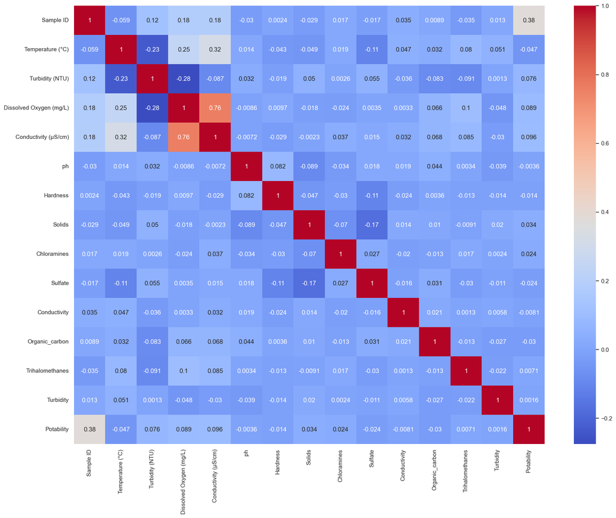

```python
corr = df.corr()
# plot the heat map
fig, ax = plt.subplots(figsize=(20,15))
sns.heatmap(corr, annot=True, ax=ax, cmap = 'coolwarm')
fig.savefig('Heat map of project.png')
```

```python
water_backup.sort_index(ascending = True, axis=1)
```

| Sample ID | Chloramines | Conductivity | Conductivity (µS/cm) | Dissolved Oxygen (mg/L) | Hardness | Organic_carbon | Potability | Solids | Sulfate | Temperature (°C) | Trihalomethanes | Turbidity | Turbidity (NTU) | ph |
| --- | --- | --- | --- | --- | --- | --- | --- | --- | --- | --- | --- | --- | --- | --- |
| 1.0 | 7.300212 | 564.308654 | 342.0 | 7.8 | 204.890456 | 10.379783 | 0 | 20791.31898 | 368.516441 | 23.1 | 86.990970 | 2.963135 | 4.5 | NaN |
| 2.0 | 6.635246 | 592.885359 | 335.0 | 6.2 | 129.422921 | 15.180013 | 0 | 18630.05786 | NaN | 22.3 | 56.329076 | 4.500656 | 5.1 | 3.716080 |
| 3.0 | 9.275884 | 418.606213 | 356.0 | 8.3 | 224.236259 | 16.868637 | 0 | 19909.54173 | NaN | 21.5 | 66.420093 | 3.055934 | 3.9 | 8.099124 |
| 4.0 | 8.059332 | 363.266516 | 327.0 | 9.5 | 214.373394 | 18.436525 | 0 | 22018.41744 | 356.886136 | 22.9 | 100.341674 | 4.628771 | 3.2 | 8.316766 |
| 5.0 | 6.546600 | 398.410813 | 352.0 | 8.1 | 181.101509 | 11.558279 | 0 | 17978.98634 | 310.135738 | 20.7 | 31.997993 | 4.075075 | 3.8 | 9.092223 |
| ... | ... | ... | ... | ... | ... | ... | ... | ... | ... | ... | ... | ... | ... | ... |
| NaN | 7.166639 | 526.424171 | NaN | NaN | 193.681736 | 13.894419 | 1 | 47580.99160 | 359.948574 | NaN | 66.687695 | 4.435821 | NaN | 4.668102 |
| NaN | 8.061362 | 392.449580 | NaN | NaN | 193.553212 | 19.903225 | 1 | 17329.80216 | NaN | NaN | NaN | 2.798243 | NaN | 7.808856 |
| NaN | 7.350233 | 432.044783 | NaN | NaN | 175.762646 | 11.039070 | 1 | 33155.57822 | NaN | NaN | 69.845400 | 3.298875 | NaN | 9.419510 |
| NaN | 6.303357 | 402.883113 | NaN | NaN | 230.603758 | 11.168946 | 1 | 11983.86938 | NaN | NaN | 77.488213 | 4.708658 | NaN | 5.126763 |
| NaN | 7.509306 | 327.459761 | NaN | NaN | 195.102299 | 16.140368 | 1 | 17404.17706 | NaN | NaN | 78.698446 | 2.309149 | NaN | 7.874671 |

## We can come to a conclusion that after sorting column in ascending order

```python
water_backup.sort_values('ph')
```

| Sample ID | Temperature (°C) | Turbidity (NTU) | Dissolved Oxygen (mg/L) | Conductivity (µS/cm) | ph | Hardness | Solids | Chloramines | Sulfate | Conductivity | Organic_carbon | Trihalomethanes | Turbidity | Potability |
| --- | --- | --- | --- | --- | --- | --- | --- | --- | --- | --- | --- | --- | --- | --- |
| NaN | NaN | NaN | NaN | NaN | 0.000000 | 214.846144 | 49456.587110 | 7.897539 | NaN | 583.448849 | 7.702328 | 77.712891 | 4.928840 | 0 |
| NaN | NaN | NaN | NaN | NaN | 0.227499 | 152.530111 | 39028.599340 | 3.462492 | 283.693782 | 443.029232 | 13.201943 | 62.322711 | 3.545741 | 1 |
| NaN | NaN | NaN | NaN | NaN | 0.975578 | 221.204114 | 31145.110740 | 7.615583 | 333.677843 | 439.112765 | 21.145954 | NaN | 2.533996 | 0 |
| NaN | NaN | NaN | NaN | NaN | 0.989912 | 133.216942 | 16922.853900 | 9.293289 | 444.375731 | 322.291191 | 10.430076 | 43.578466 | 5.160604 | 1 |
| NaN | NaN | NaN | NaN | NaN | 1.431782 | 228.130383 | 12937.246890 | 6.214773 | 319.734136 | 495.379883 | 12.033344 | 61.141119 | 4.948443 | 0 |
| ... | ... | ... | ... | ... | ... | ... | ... | ... | ... | ... | ... | ... | ... | ... |
| NaN | NaN | NaN | NaN | NaN | NaN | 198.218700 | 31081.735260 | 7.419106 | NaN | 517.925946 | 11.711419 | 85.428785 | 3.345543 | 1 |
| NaN | NaN | NaN | NaN | NaN | NaN | 203.204659 | 10643.186770 | 6.828936 | NaN | 384.597711 | 16.011328 | 72.911573 | 3.065910 | 1 |
| NaN | NaN | NaN | NaN | NaN | NaN | 225.754109 | 28194.452650 | 5.892830 | 366.201583 | 418.272901 | 17.306832 | 103.912548 | 3.855895 | 1 |
| NaN | NaN | NaN | NaN | NaN | NaN | 188.536608 | 24711.414930 | 7.129520 | NaN | 555.548534 | 16.959269 | 56.038702 | 4.331691 | 1 |
| NaN | NaN | NaN | NaN | NaN | NaN | 134.736856 | 9000.025591 | 9.026293 | NaN | 428.213987 | 8.668672 | 74.773392 | 3.699558 | 1 |

## We can come to a conclusion that after sorting the value of ph in ascending order

## We come to a conclusion that distribution of sulfate in water in the dataset. They are substances naturally present in minerals, soil and rocks. Water containing less than 500 milligrams of sulfate is safe to drink

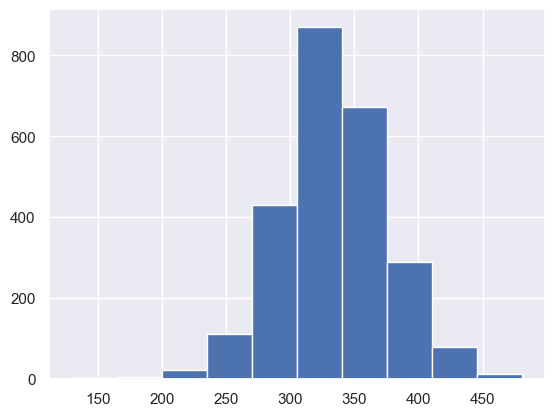

```python
df['Sulfate'].hist()
```

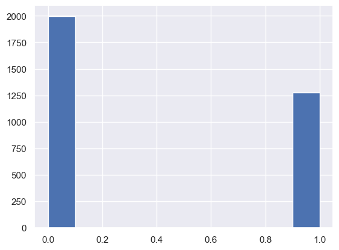

```python
df['Potability'].hist()
```

## We come to a conclusion that Potability column of this dataset is the column we need to predict because it contains values 0 and 1 that indicate whether the water is potable (1) or unfit (0) for consumption

```python
Input = df.drop('Potability',axis =1)
Input
```

|  | Sample ID | Temperature (°C) | Turbidity (NTU) | Dissolved Oxygen (mg/L) | Conductivity (µS/cm) | ph | Hardness | Solids | Chloramines | Sulfate | Conductivity | Organic_carbon | Trihalomethanes | Turbidity |
| --- | --- | --- | --- | --- | --- | --- | --- | --- | --- | --- | --- | --- | --- | --- |
| 0 | 1.0 | 23.1 | 4.5 | 7.8 | 342.0 | NaN | 204.890456 | 20791.31898 | 7.300212 | 368.516441 | 564.308654 | 10.379783 | 86.990970 | 2.963135 |
| 1 | 2.0 | 22.3 | 5.1 | 6.2 | 335.0 | 3.716080 | 129.422921 | 18630.05786 | 6.635246 | NaN | 592.885359 | 15.180013 | 56.329076 | 4.500656 |
| 2 | 3.0 | 21.5 | 3.9 | 8.3 | 356.0 | 8.099124 | 224.236259 | 19909.54173 | 9.275884 | NaN | 418.606213 | 16.868637 | 66.420093 | 3.055934 |
| 3 | 4.0 | 22.9 | 3.2 | 9.5 | 327.0 | 8.316766 | 214.373394 | 22018.41744 | 8.059332 | 356.886136 | 363.266516 | 18.436525 | 100.341674 | 4.628771 |
| 4 | 5.0 | 20.7 | 3.8 | 8.1 | 352.0 | 9.092223 | 181.101509 | 17978.98634 | 6.546600 | 310.135738 | 398.410813 | 11.558279 | 31.997993 | 4.075075 |
| ... | ... | ... | ... | ... | ... | ... | ... | ... | ... | ... | ... | ... | ... | ... |
| 3271 | NaN | NaN | NaN | NaN | NaN | 4.668102 | 193.681736 | 47580.99160 | 7.166639 | 359.948574 | 526.424171 | 13.894419 | 66.687695 | 4.435821 |
| 3272 | NaN | NaN | NaN | NaN | NaN | 7.808856 | 193.553212 | 17329.80216 | 8.061362 | NaN | 392.449580 | 19.903225 | NaN | 2.798243 |
| 3273 | NaN | NaN | NaN | NaN | NaN | 9.419510 | 175.762646 | 33155.57822 | 7.350233 | NaN | 432.044783 | 11.039070 | 69.845400 | 3.298875 |
| 3274 | NaN | NaN | NaN | NaN | NaN | 5.126763 | 230.603758 | 11983.86938 | 6.303357 | NaN | 402.883113 | 11.168946 | 77.488213 | 4.708658 |
| 3275 | NaN | NaN | NaN | NaN | NaN | 7.874671 | 195.102299 | 17404.17706 | 7.509306 | NaN | 327.459761 | 16.140368 | 78.698446 | 2.309149 |

3276 rows × 14 columns

```python
Output = df['Potability']
Output
```

```
0       0
1       0
2       0
3       0
4       0
       ..
3271    1
3272    1
3273    1
3274    1
3275    1
Name: Potability, Length: 3276, dtype: int64
```

```python
from sklearn.model_selection import train_test_split
X_train, X_test, y_train, y_test = train_test_split(Input, Output, test_size = 0.2, random_state=0)
```